# Recognition and Classification of the Quality of Human Activity using Random Forests.

Mashudu

Sunday, June 21, 2015

## Summary

Using a dataset of 152 collected and calculated features from 4 human activity monitors worn by 6 individuals, we use a random forest algorytm with cross validation to propose a model for classifying a given activity, barbell lifts, according to 1 of 5 qualitative classes which represent 1 correct and 4 distinct incorrect ways of performing the exercise.

## Background

Using devices such as Jawbone Up, Nike FuelBand, and Fitbit it is now possible to collect a large amount of data about personal activity relatively inexpensively. These type of devices are part of the quantified self movement - a group of enthusiasts who take measurements about themselves regularly to improve their health, to find patterns in their behavior, or because they are tech geeks. One thing that people regularly do is quantify how much of a particular activity they do, but they rarely quantify how well they do it. In this analysis, we use data from accelerometers on the belt, forearm, arm, and dumbell of 6 participants. The section on the Weight Lifting Exercise Dataset, on the dataset author’s website has the following information:

> The approach we propose for the Weight Lifting Exercises dataset is to investigate “how (well)” an activity was performed by the wearer. The “how (well)” investigation has only received little attention so far, even though it potentially provides useful information for a large variety of applications,such as sports training.

> we first define quality of execution and investigate three aspects that pertain to qualitative activity recognition: the problem of specifying correct execution, the automatic and robust detection of execution mistakes, and how to provide feedback on the quality of execution to the user.

> Six young health participants were asked to perform one set of 10 repetitions of the Unilateral Dumbbell Biceps Curl in five different fashions: exactly according to the specification (Class A), throwing the elbows to the front (Class B), lifting the dumbbell only halfway (Class C), lowering the dumbbell only halfway (Class D) and throwing the hips to the front (Class E).

> Class A corresponds to the specified execution of the exercise, while the other 4 classes correspond to common mistakes. Participants were supervised by an experienced weight lifter to make sure the execution complied to the manner they were supposed to simulate. The exercises were performed by six male participants aged between 20-28 years, with little weight lifting experience. We made sure that all participants could easily simulate the mistakes in a safe and controlled manner by using a relatively light dumbbell (1.25kg).

## Data Processing

You can download the training dataset [here](https://d396qusza40orc.cloudfront.net/predmachlearn/pml-training.csv).

Further information and data about the original experiment can be found at the data author’s website [here](http://groupware.les.inf.puc-rio.br/har#weight_lifting_exercises)

The following code downloads, loads and using package *caret* splits the training dataset into a model training part (70%) and a part to validate the final model with (30%). The data consists 160 features: 7 features that identify the exercise participant, the UTC date and time the activity was recorded, and the time shift window used for summarizing contiguous samples/activity records. 152 features collected from the sensors or calculated from sensor data using the time windows. 1 outcome feature, named “classe” identifies the class of activity (A,B,C,D or E) that the participant was performing at that point in time.

```r
## download the data
if(!file.exists("pml-training.csv")) {
    download.file(train_url, "pml-training.csv")
}
if(!file.exists("pml-testing.csv"))  {
    download.file(test_url,  "pml-testing.csv")
}

## load the training dataset
train <- read.csv(file = "pml-training.csv", header = TRUE, sep = ",")
# object.size(train)

## partition loaded training dataset into a training and validation set
set.seed(538)
library(caret, quietly = T, warn.conflicts = F)
inTrain <- createDataPartition(y = train$classe, p = 0.7, list = F)
wle_train <- train[inTrain,]
wle_validation <- train[-inTrain,]
rm(train)
```

Creating a data frame called *feature_info* (the code is available in the R Markdown file) from our training partition of 13737 records/acitivity samples, we can look at which features are not likely to contribute to our classification model. We identify 37 features most likely to contribute to the model because they have no missing values (features with missing values were missing 98% of values or more), don’t lack variablity and are not highly correlated (absolute cut-off of 0.8 used) with the rest of the dataset features.

```r
## select features to keep that are not highly correlated, lack variability or mostly NA

table(feature_info[,6]) # features have near zero variance
```

```
##
## FALSE  TRUE
##   131    29
```

```r
table(feature_info[,7]) # features have missing values
```

```
##
## FALSE  TRUE
##    60   100
```

```r
table(feature_info[,8]) # features are highly correlated with many features
```

```
##
## FALSE  TRUE
##    98    62
```

```r
# table(feature_info[,c(6:8)])

# how many features don't contain NA's, have variability and are not highly correlated with the feature set
sum(feature_info[6] == F & feature_info[7] == F & feature_info[8] == F)
```

```
## [1] 44
```

```r
## keep features which don't contain NA's, have variability and are not highly correlated with the feature set
keep_features <- which(feature_info[6] == F & feature_info[7] == F & feature_info[8] == F)
wle_train <- wle_train[,(keep_features)]
wle_train <- wle_train[,-c(1:6)]
```

## Model selection

Random Forests are a good choice to classify data with a large number of features accurately where no known or simple linear relationship can be proposed without further information to suggest a hypothesis. Random forests also provide THAT further information by identifying the features that are important to deciding classification accurately.

We use Random Forests here in combination with cross-validation to explore and accurately classify this activity data by “classe”

First the *randomForest* package is loaded and a random seed set so results are reproducible. We create a training control that that will use 4-fold cross-validation and use the same random seed to keep the results reproducible every time this model is built.

```r
## fit a random forests model
library(randomForest, quietly = T, warn.conflicts = F)

# set the seeds for the training controls so results are reproducible
set.seed(538)
seeds <- vector(mode = "list", length = 5)
for(i in 1:4) seeds[[i]]<- sample.int(n=999, 3)
seeds[[5]]<-sample.int(999, 1)
# the seed object should be a list of length 5 with 4 integer vectors of size 3
# and the last list element having a single integer

# set the training model controls
library(caret, quietly = T, warn.conflicts = F)
train_control <- trainControl(method = "cv", number = 4, seeds = seeds)
```

For a baseline we check what forests with 21 trees and no cross-vaidation show versus forests with 21 trees and cross-validation:

```r
# no cross-validation & 21 trees
fit_rf1 <- train(classe ~ ., data = wle_train, method = "rf", importance = T,
                 ntree = 21, trControl = trainControl(method = "oob", seeds = 538))
# cross-validation & 21 trees
set.seed(538)
fit_rf2 <- train(classe ~ ., data = wle_train, method = "rf", importance = T,
                 ntree = 21, trControl = train_control)
```

The 21 tree model without cross-validation already performs well achieving an OOB estimate for the error rate of 2.24%

```
## Random Forest
##
## 13737 samples
##    37 predictor
##     5 classes: 'A', 'B', 'C', 'D', 'E'
##
## No pre-processing
## Resampling results across tuning parameters:
##
##   mtry  Accuracy   Kappa
##    2    0.9642571  0.9547647
##   19    0.9764869  0.9702456
##   37    0.9635292  0.9538476
##
## Accuracy was used to select the optimal model using  the largest value.
## The final value used for the model was mtry = 19.
```

```
##
## Call:
##  randomForest(x = x, y = y, ntree = 21, mtry = param$mtry, importance = ..1)
##                Type of random forest: classification
##                      Number of trees: 21
## No. of variables tried at each split: 19
##
##         OOB estimate of  error rate: 2.24%
## Confusion matrix:
##      A    B    C    D    E class.error
## A 3888   11    2    3    1 0.004353393
## B   57 2562   20   11    7 0.035754610
## C    5   42 2325   16    7 0.029227557
## D    8    8   61 2166    9 0.038188277
## E    3   11    8   17 2486 0.015445545
```

```
## Random Forest
##
## 13737 samples
##    37 predictor
##     5 classes: 'A', 'B', 'C', 'D', 'E'
##
## No pre-processing
## Resampling: Cross-Validated (4 fold)
##
## Summary of sample sizes: 10301, 10302, 10304, 10304
##
## Resampling results across tuning parameters:
##
##   mtry  Accuracy   Kappa      Accuracy SD  Kappa SD
##    2    0.9769242  0.9707977  0.003619657  0.004587673
##   19    0.9817283  0.9768763  0.002650217  0.003359784
##   37    0.9681151  0.9596529  0.006175608  0.007819042
##
## Accuracy was used to select the optimal model using  the largest value.
## The final value used for the model was mtry = 19.
```

```
##
## Call:
##  randomForest(x = x, y = y, ntree = 21, mtry = param$mtry, importance = ..1)
##                Type of random forest: classification
##                      Number of trees: 21
## No. of variables tried at each split: 19
##
##         OOB estimate of  error rate: 2.45%
## Confusion matrix:
##      A    B    C    D    E class.error
## A 3887   11    2    4    2 0.004864311
## B   68 2537   33   11    9 0.045522950
## C    4   42 2330   14    6 0.027545910
## D    5   14   72 2156    5 0.042628774
## E    0    6   12   16 2491 0.013465347
```

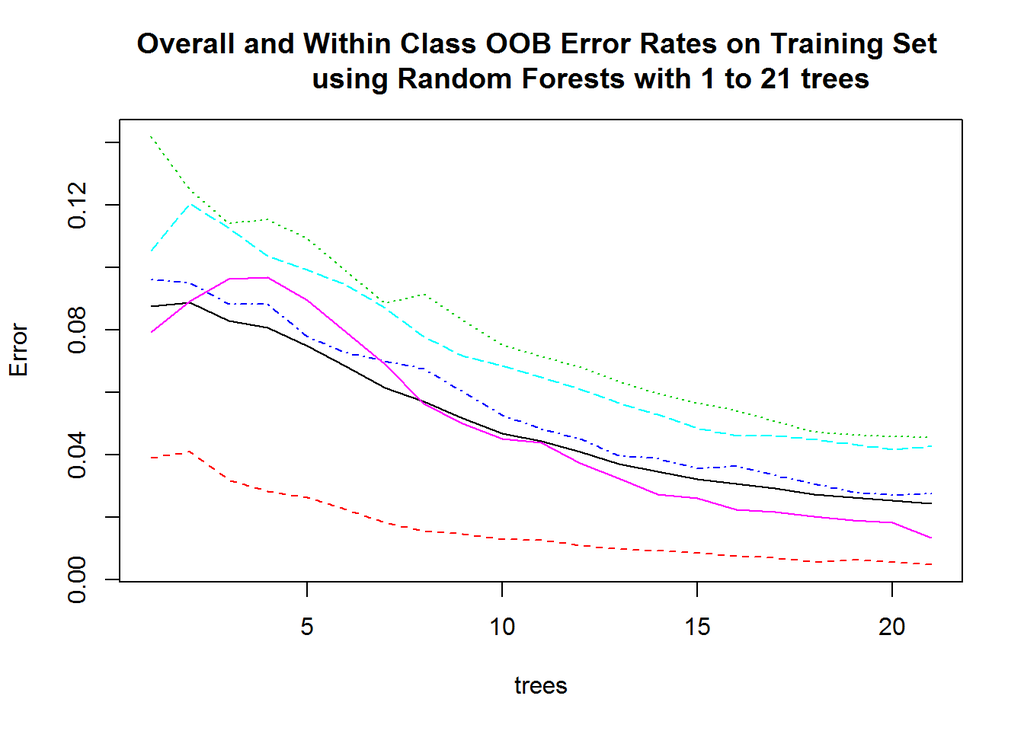

So we proceed to a cross-validated random forests model with 51 trees:

```r
# random forests with 51 trees and cross-validation
fit_rf3 <- train(classe ~ ., data = wle_train, method = "rf", importance = T,
                 ntree = 51, trControl = train_control)
```

```
## Random Forest
##
## 13737 samples
##    37 predictor
##     5 classes: 'A', 'B', 'C', 'D', 'E'
##
## No pre-processing
## Resampling: Cross-Validated (4 fold)
##
## Summary of sample sizes: 10302, 10302, 10304, 10303
##
## Resampling results across tuning parameters:
##
##   mtry  Accuracy   Kappa      Accuracy SD  Kappa SD
##    2    0.9836937  0.9793651  0.002204766  0.002792096
##   19    0.9831113  0.9786308  0.002843414  0.003598189
##   37    0.9705174  0.9626961  0.005261276  0.006661731
##
## Accuracy was used to select the optimal model using  the largest value.
## The final value used for the model was mtry = 2.
```

```
##
## Call:
##  randomForest(x = x, y = y, ntree = 51, mtry = param$mtry, importance = ..1)
##                Type of random forest: classification
##                      Number of trees: 51
## No. of variables tried at each split: 2
##
##         OOB estimate of  error rate: 1.62%
## Confusion matrix:
##      A    B    C    D    E class.error
## A 3900    4    1    1    0 0.001536098
## B   53 2570   29    4    2 0.033107600
## C    3   33 2356    2    2 0.016694491
## D    1    0   64 2181    6 0.031527531
## E    0    3    6    8 2508 0.006732673
```

The Variable Importance for 25 of the 37 features that stand out most in the final model is ploted in two plots below. The feature that apears most important using the *Mean Decrease in Accuracy* when it is omitted is belt sensor pitch (*pitch_belt*). The feature that apears most important using the *Mean Decrease in Gini Impurity* is the dumbbell magnetometer on the Z vector (*magnet__dumbbell_z*) with belt sensor pitch second.

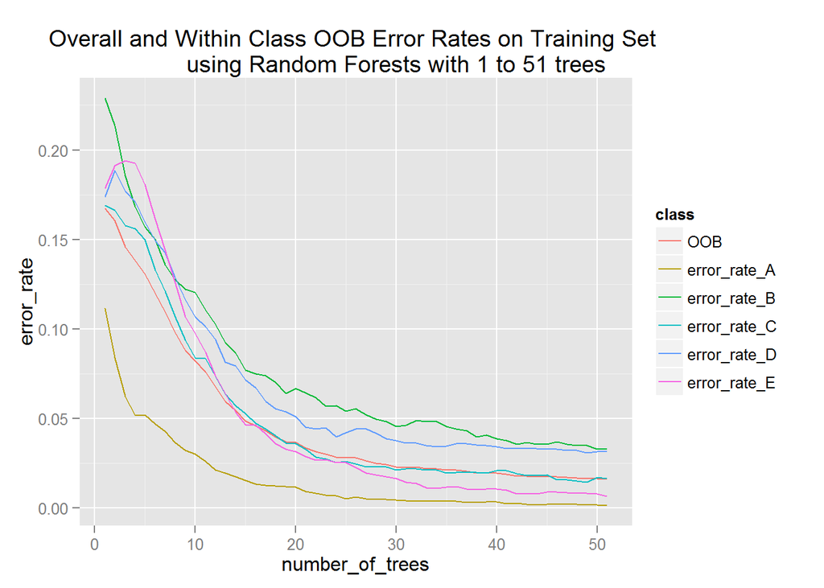

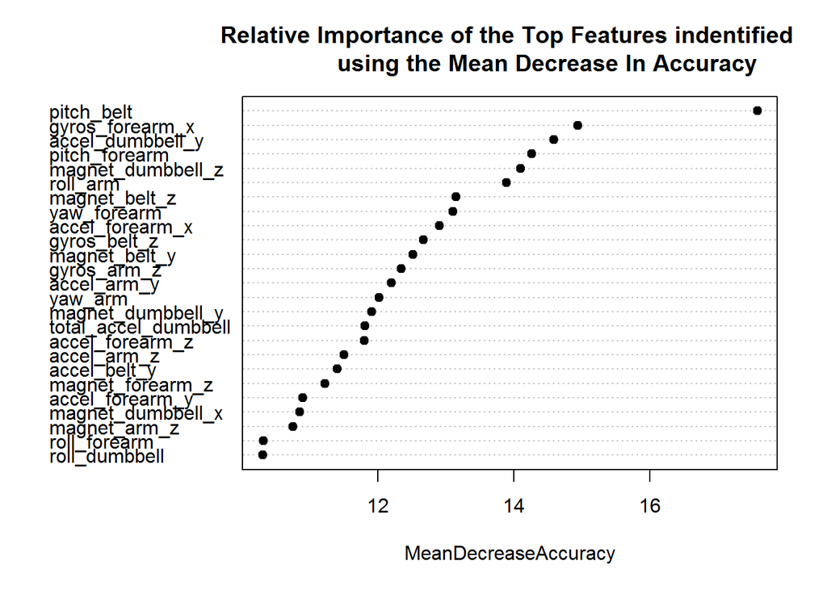

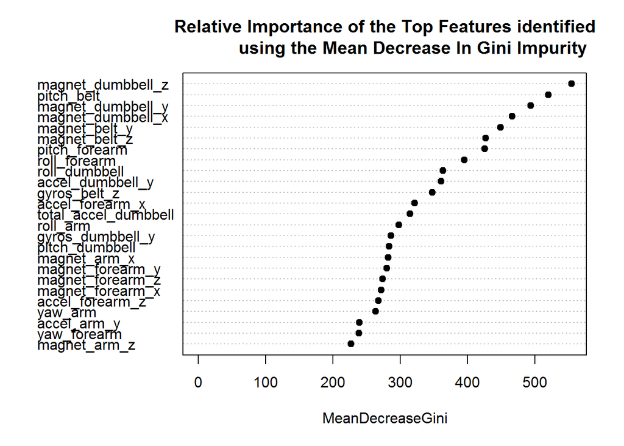

## Results

Validation of the final model on a set of 5885 samples/activity records kept out of training whe the the original dataset was split, produces the following performance output:

```
## Confusion Matrix and Statistics
##
##           Reference
## Prediction    A    B    C    D    E
##          A 1670    9    0    0    0
##          B    3 1126    8    0    0
##          C    0    4 1017   33    0
##          D    1    0    1  929    2
##          E    0    0    0    2 1080
##
## Overall Statistics
##
##                Accuracy : 0.9893
##                  95% CI : (0.9863, 0.9918)
##     No Information Rate : 0.2845
##     P-Value [Acc > NIR] : < 2.2e-16
##
##                   Kappa : 0.9865
##  Mcnemar's Test P-Value : NA
##
## Statistics by Class:
##
##                      Class: A Class: B Class: C Class: D Class: E
## Sensitivity            0.9976   0.9886   0.9912   0.9637   0.9982
## Specificity            0.9979   0.9977   0.9924   0.9992   0.9996
## Pos Pred Value         0.9946   0.9903   0.9649   0.9957   0.9982
## Neg Pred Value         0.9990   0.9973   0.9981   0.9929   0.9996
## Prevalence             0.2845   0.1935   0.1743   0.1638   0.1839
## Detection Rate         0.2838   0.1913   0.1728   0.1579   0.1835
## Detection Prevalence   0.2853   0.1932   0.1791   0.1585   0.1839
## Balanced Accuracy      0.9977   0.9931   0.9918   0.9814   0.9989
```

The predicted “classe” for the 20 samples for which “classe” is unknown are calculated, listed and filed for upload below:

```
##  [1] B A B A A E D B A A B C B A E E A B B B
## Levels: A B C D E
```